# Assignment 3B - Window Functions

Author

Ellie Wilser

## Introduction

For this assignment, I will be analyzing electricity sales from commercial customers. This category is where data centers are listed under by the U.S. Energy Information Administration (EIA). I will find the trend in electricity prices from 2015 to current, and see if there as been a significant increase that coincides with the rise of data centers.

## Approach

I used Gemini to recommend a data source for me to use. This is the prompt I used:

“I am working on an assignment that requires a data source with time series for 2 or more separate items. I am particularly interested in a data source that is related to energy usage or cost. Please list 5 data sources I could particularly use”

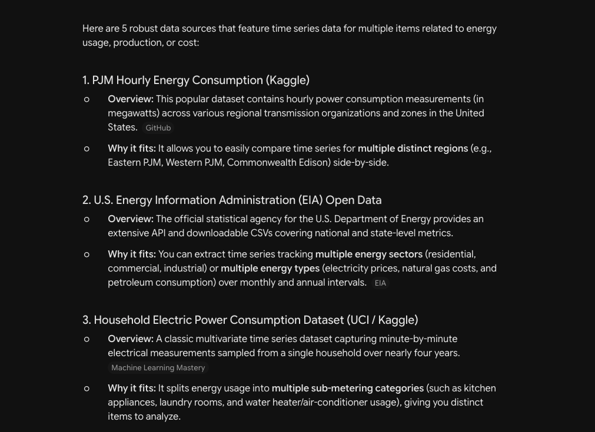

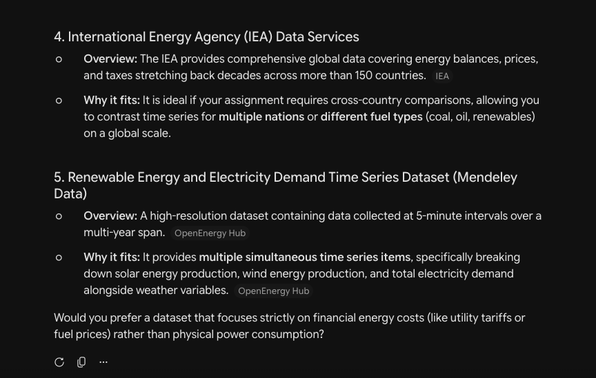

This answer is where I found the data set I will be using ([Link to data set source](https://www.eia.gov/opendata/browser/electricity/retail-sales)). I used the EIA API to download the JSON file with the data set I will be using. The JSON file is stored in GitHub I will be reading it into R using the jsonlite package.

I will be using different window functions throughout the assignment to answer varies business questions. I will be implementing the window functions in SQL and in Dplyr to get more practice in both. As well, I will practice different visualizations in ggplot2 and use Github throughout the assignment.

## Code

### Business Questions

I want to focus on electricity prices in Virginia because of their abundance of data centers. These are the business questions I plan to answer throughout the assignment.

Question 1: What is the trend in Virginia’s Energy Price’s over the past 10 years?

Question 2: What were the 10 top most expensive months for electricity in Virginia during the past 10 years?

Question 3: Were there any relative maximum or spikes in energy prices?

### Library

```r
library(jsonlite)
library(dplyr)
library(slider)
library(lubridate)
library(DBI)
library(ggplot2)
```

```r
con <- dbConnect(
  RPostgres::Postgres(),
  dbname   = "Assignment_2",
  host     = "localhost",
  port     = 5432,
  user     = "postgres"
)
```

### Window Functions in Dplyr

First I will create a rolling 6 month average and a year to date average using window functions in Dplyr. I want to call out the slider library I used and lubridate library. The slider library allowed me to lag my window function by 6 months to get the rolling average. Lubridate is a library that makes working with dates a lot easier in R.

Documentation on the slider library can be found here ([Link to Slider Documentation](https://slider.r-lib.org/reference/slide.html)).

Documentation for the lubridate library can be found here ([Link to Lubridate Documentation](https://lubridate.tidyverse.org/)).

Using the jsonLite package in R made loading the data file extremely easy. This was one of my main concerns with this assignment and the data that I found.

```r
energy_consumption <- fromJSON("https://raw.githubusercontent.com/EllieWilser/Data_607/refs/heads/main/Assignment_3/electricty_consumption_eia.json")


energy_consumption <- energy_consumption$response$data

energy_consumption <- energy_consumption %>%
  mutate(
    period = as.Date(paste0(period, "-01")),
    year = year(period)
  )
```

Next I created a dataframe energy_analyze which is the energy consumption data with 2 extra columns, ytd average and rolling 6 month mean.

```r
energy_analyze <- energy_consumption %>%
  arrange(stateid, period) %>%
  mutate(year = year(period),
         price=as.numeric(price)) %>%

  # YTD Average
  group_by(stateid, year) %>%
  mutate(ytd_avg = cummean(price)) %>%
  ungroup() %>%

  # Six Month Moving Average
  group_by(stateid) %>%
  arrange(period,.by_group = TRUE) %>%
  mutate(
    rolling_6m_mean = slide_index_dbl(
      .x = as.numeric(price),
      .i= period,
      .f = mean,
      .before = months(6),
      .complete = FALSE
    )
  ) %>%
  ungroup()
```

### Window Functions in SQL

During the meetup last week, someone presented their SQL and showed how they connected their R environment to PostgreSQL. I did that for this assignment, and was able to do all my queries and create a table from RStudio. I found this extremely useful as working with the PostgreSQL IDE can be challenging.

```r
library(DBI)

dbWriteTable(
  conn = con,
  name = "energy_consumption",
  value = energy_consumption,
  overwrite = TRUE,
  row.names = FALSE
)
```

For my SQL query, I found it easier to create a CTE cleaned_data to fix the data type instead of querying the data directly. Overall, I preferred doing the window functions in SQL over Dplyr because to me it was more straight forward and logical.

```sql
-- CTE Cleaned Data that fixes types
with cleaned_data as (
  SELECT
    stateid,
    period,
    CAST(price as FLOAT) as price,
    EXTRACT(YEAR FROM period) as YEAR
  FROM energy_consumption
)

SELECT
    stateid,
    period,
    price,
    year,

    -- YTD Average
    AVG(price) OVER (
        PARTITION BY stateid, year
        ORDER BY period
        ROWS BETWEEN UNBOUNDED PRECEDING AND CURRENT ROW
    ) AS ytd_avg,

    -- Six Month Moving Average
    AVG(price) OVER (
        PARTITION BY stateid
        ORDER BY period
        RANGE BETWEEN INTERVAL '6' MONTH PRECEDING AND CURRENT ROW
    ) AS rolling_6m_mean

FROM cleaned_data
ORDER BY stateid, period;
```

Displaying records 1 - 10

| stateid | period | price | year | ytd_avg | rolling_6m_mean |
| --- | --- | --- | --- | --- | --- |
| VA | 2015-01-01 | 8.45 | 2015 | 8.450000 | 8.450000 |
| VA | 2015-02-01 | 8.50 | 2015 | 8.475000 | 8.475000 |
| VA | 2015-03-01 | 8.45 | 2015 | 8.466667 | 8.466667 |
| VA | 2015-04-01 | 8.19 | 2015 | 8.397500 | 8.397500 |
| VA | 2015-05-01 | 8.14 | 2015 | 8.346000 | 8.346000 |
| VA | 2015-06-01 | 8.21 | 2015 | 8.323333 | 8.323333 |
| VA | 2015-07-01 | 8.17 | 2015 | 8.301429 | 8.301429 |
| VA | 2015-08-01 | 8.10 | 2015 | 8.276250 | 8.251429 |
| VA | 2015-09-01 | 8.10 | 2015 | 8.256667 | 8.194286 |
| VA | 2015-10-01 | 8.03 | 2015 | 8.234000 | 8.134286 |

### Answers to Business Questions

To find the top 10 highest price months, I used the rolling 6 month average, so not to include seasonal spikes. I found that there was a relative maximum or spike in January of 2023 that was similar to the prices that Virginia is seeing now.

```r
top_10_months <- energy_analyze %>%
  arrange(desc(rolling_6m_mean)) %>%
  head(10)

top_10_months
```

| period | stateid | stateDescription | sectorid | sectorName | price | revenue | sales | price-units | revenue-units | sales-units | year | ytd_avg | rolling_6m_mean |
| --- | --- | --- | --- | --- | --- | --- | --- | --- | --- | --- | --- | --- | --- |
| 2026-06-01 | VA | Virginia | COM | commercial | 10.99 | 853.93221 | 7770.6686 | cents per kilowatt-hour | million dollars | million kilowatt hours | 2026 | 11.126667 | 10.99571 |
| 2026-05-01 | VA | Virginia | COM | commercial | 10.84 | 784.20026 | 7233.94585 | cents per kilowatt-hour | million dollars | million kilowatt hours | 2026 | 11.154000 | 10.89429 |
| 2026-04-01 | VA | Virginia | COM | commercial | 10.33 | 705.43678 | 6831.525 | cents per kilowatt-hour | million dollars | million kilowatt hours | 2026 | 11.232500 | 10.79571 |
| 2026-03-01 | VA | Virginia | COM | commercial | 10.16 | 688.21545 | 6772.20406 | cents per kilowatt-hour | million dollars | million kilowatt hours | 2026 | 11.533333 | 10.74286 |
| 2026-02-01 | VA | Virginia | COM | commercial | 13.01 | 856.75768 | 6587.41893 | cents per kilowatt-hour | million dollars | million kilowatt hours | 2026 | 12.220000 | 10.64286 |
| 2026-01-01 | VA | Virginia | COM | commercial | 11.43 | 836.50941 | 7316.66472 | cents per kilowatt-hour | million dollars | million kilowatt hours | 2026 | 11.430000 | 10.24286 |
| 2023-01-01 | VA | Virginia | COM | commercial | 9.99 | 531.43345 | 5319.00834 | cents per kilowatt-hour | million dollars | million kilowatt hours | 2023 | 9.990000 | 10.21286 |
| 2022-12-01 | VA | Virginia | COM | commercial | 10.25 | 583.50873 | 5692.95889 | cents per kilowatt-hour | million dollars | million kilowatt hours | 2022 | 9.618333 | 10.15429 |
| 2023-02-01 | VA | Virginia | COM | commercial | 9.19 | 493.71912 | 5373.83568 | cents per kilowatt-hour | million dollars | million kilowatt hours | 2023 | 9.590000 | 10.11429 |
| 2022-11-01 | VA | Virginia | COM | commercial | 9.84 | 588.64937 | 5980.15058 | cents per kilowatt-hour | million dollars | million kilowatt hours | 2022 | 9.560909 | 10.08286 |

Next, I created a graph in ggplot to see the overall trend in energy prices. Currently, prices are spiking fast and Virginia’s electricity cost is the highest it’s seen before. However, this looks very similar to the spike in 2023. This new spike in price we are seeing started in 2025 which coincides with the rise of AI and data centers in the state. As a reminder, this data is only for commercial customers in the state, which is where data centers are grouped.

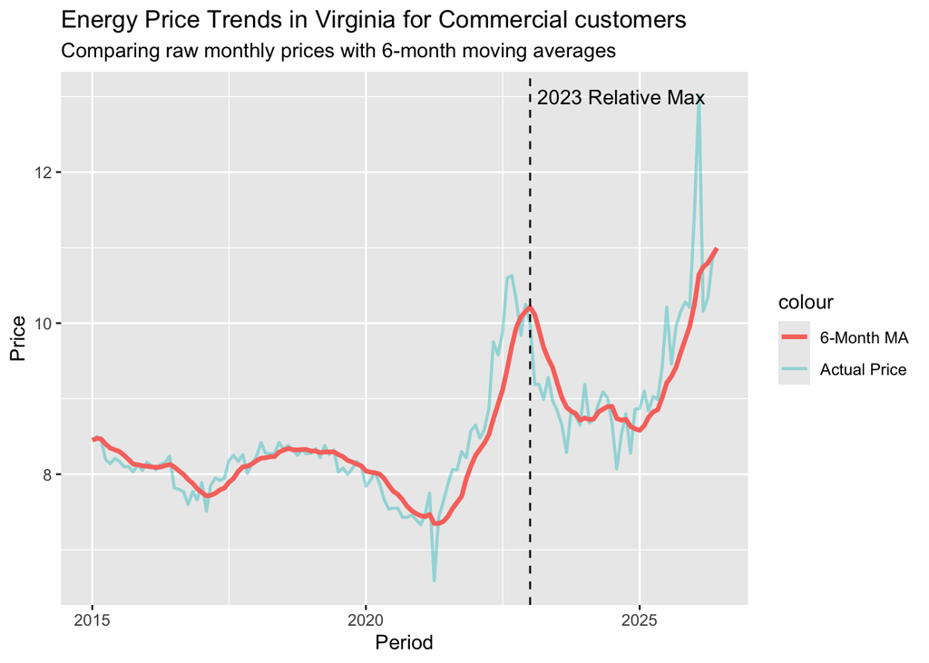

```r
energy_analyze %>%
  ggplot(aes(x = period)) +
  geom_line(aes(y = price, color = "Actual Price"), alpha = 0.4, linewidth = 0.8) +
  geom_line(aes(y = rolling_6m_mean, color = "6-Month MA"), linewidth = 1.2)+
  geom_vline(
    xintercept = as.Date("2023-01-01"),
    linetype = "dashed",

  ) +
  annotate("text",x=as.Date("2024-09-01"),y=13,label="2023 Relative Max")+

  labs(
    title = "Energy Price Trends in Virginia for Commercial customers",
    subtitle = "Comparing raw monthly prices with 6-month moving averages",
    x = "Period",
    y = "Price"
  )
```